# Transportation

## Burner Express Bus

*Data presented on this page describe Burner Express Bus travel, but **do not** include data from passengers on Burner Express Air, which was introduced in 2016.*

## Reason(s) for Choosing Burner Express Bus*

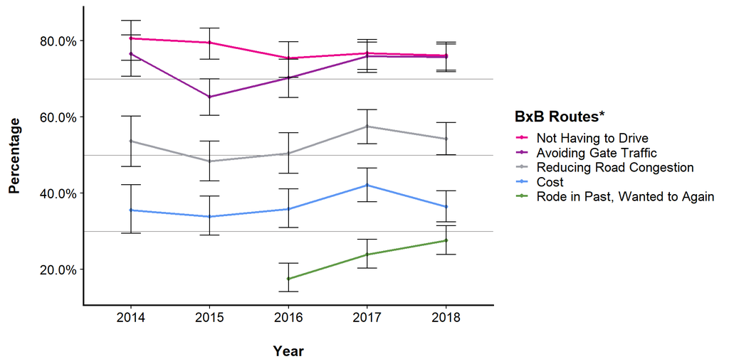

Error bars indicate the upper and lower bounds of the 95% confidence intervals.

* Participants selected all option(s) that applied. Data in the plot above and table below represent participants who reported traveling to BRC via Burner Express Bus.  
** The option "I've used Burner Express in the past and wanted to do it again" was first provided in the 2016 online survey.

|  | 2014 Percent | 2014 MoE +/- % |  | 2015 Percent | 2015 MoE +/- % |  | 2016 Percent | 2016 MoE +/- % |  | 2017 Percent | 2017 MoE +/- % |  | 2018 Percent | 2018 MoE +/- % |
| --- | --- | --- | --- | --- | --- | --- | --- | --- | --- | --- | --- | --- | --- | --- |
| Not Having to Drive | 80.6 | 5.3 |  | 79.5 | 4.1 |  | 75.4 | 4.7 |  | 76.7 | 3.9 |  | 76.1 | 3.7 |
| Avoiding Gate Traffic | 76.5 | 5.5 |  | 65.3 | 4.9 |  | 70.3 | 4.9 |  | 75.9 | 3.9 |  | 75.7 | 3.5 |
| Reducing Road Congestion | 53.7 | 6.7 |  | 48.4 | 5.3 |  | 50.5 | 5.3 |  | 57.5 | 4.5 |  | 54.3 | 4.1 |
| Cost | 35.6 | 6.3 |  | 33.9 | 5.1 |  | 35.9 | 5.1 |  | 42.1 | 4.5 |  | 36.5 | 4.1 |
| Rode in Past, Wanted to Again | NA | NA |  | NA | NA |  | 17.6 | 3.7 |  | 23.9 | 3.7 |  | 27.6 | 3.7 |

## Evaluation of Overall Burner Express Bus Experience*

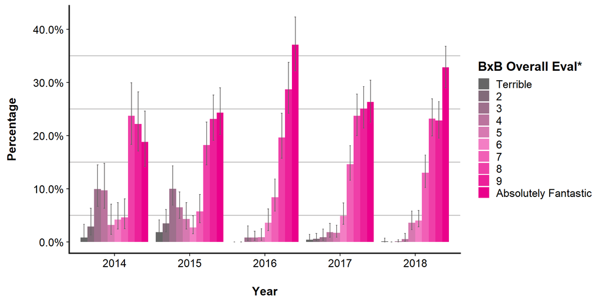

Error bars indicate the upper and lower bounds of the 95% confidence intervals.

* Data in the plot above and table below represent participants who reported traveling to BRC via Burner Express Bus.

|  | 2014 Percent | 2014 MoE +/- % |  | 2015 Percent | 2015 MoE +/- % |  | 2016 Percent | 2016 MoE +/- % |  | 2017 Percent | 2017 MoE +/- % |  | 2018 Percent | 2018 MoE +/- % |
| --- | --- | --- | --- | --- | --- | --- | --- | --- | --- | --- | --- | --- | --- | --- |
| Terrible | 0.8 | 1.2 |  | 1.8 | 1.6 |  | 0.0 | 0.0 |  | 0.4 | 0.6 |  | 0.1 | 0.2 |
| 2 | 2.9 | 2.2 |  | 3.5 | 2.0 |  | 0.0 | 0.0 |  | 0.6 | 0.6 |  | 0.0 | 0.0 |
| 3 | 9.9 | 3.9 |  | 10.0 | 3.5 |  | 0.8 | 1.0 |  | 0.9 | 1.0 |  | 0.1 | 0.2 |
| 4 | 9.7 | 4.1 |  | 6.5 | 2.4 |  | 0.8 | 0.8 |  | 1.8 | 1.2 |  | 0.5 | 0.6 |
| 5 | 3.2 | 2.5 |  | 4.3 | 2.4 |  | 0.9 | 1.0 |  | 1.7 | 1.0 |  | 3.6 | 1.8 |
| 6 | 4.2 | 2.4 |  | 2.7 | 1.6 |  | 3.6 | 2.0 |  | 4.9 | 2.0 |  | 4.0 | 1.6 |
| 7 | 4.6 | 2.7 |  | 5.7 | 2.5 |  | 8.4 | 2.9 |  | 14.6 | 3.1 |  | 13.0 | 2.9 |
| 8 | 23.7 | 5.7 |  | 18.2 | 3.9 |  | 19.6 | 4.3 |  | 23.7 | 3.9 |  | 23.2 | 3.5 |
| 9 | 22.2 | 5.5 |  | 23.1 | 4.3 |  | 28.7 | 4.7 |  | 25.1 | 3.9 |  | 22.8 | 3.5 |
| Absolutely Fantastic | 18.8 | 5.3 |  | 24.3 | 4.5 |  | 37.1 | 5.1 |  | 26.3 | 3.9 |  | 32.8 | 3.9 |

## Evaluation of Burner Express Bus Ticket Price*

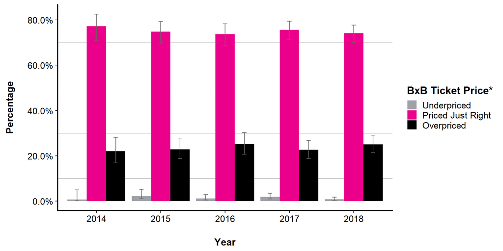

Error bars indicate the upper and lower bounds of the 95% confidence intervals.

* Data in the plot above and table below represent participants who reported traveling to BRC via Burner Express Bus. This question in the online survey specifically asks for an evaluation of ticket price based on the participant's level of satisfaction with the program.

|  | 2014 Percent | 2014 MoE +/- % |  | 2015 Percent | 2015 MoE +/- % |  | 2016 Percent | 2016 MoE +/- % |  | 2017 Percent | 2017 MoE +/- % |  | 2018 Percent | 2018 MoE +/- % |
| --- | --- | --- | --- | --- | --- | --- | --- | --- | --- | --- | --- | --- | --- | --- |
| Underpriced | 0.7 | 1.4 |  | 2.2 | 2.0 |  | 1.1 | 1.0 |  | 1.8 | 1.2 |  | 0.8 | 0.6 |
| Priced Just Right | 77.3 | 5.7 |  | 74.8 | 4.7 |  | 73.7 | 4.7 |  | 75.7 | 4.1 |  | 74.1 | 3.7 |
| Overpriced | 22.0 | 5.7 |  | 22.9 | 4.5 |  | 25.2 | 4.7 |  | 22.6 | 3.9 |  | 25.1 | 3.7 |

## Evaluation of Burner Express Bus Ticket Purchasing Experience*

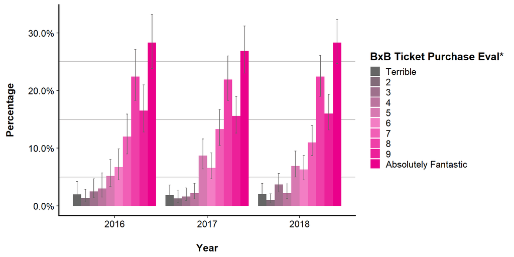

Error bars indicate the upper and lower bounds of the 95% confidence intervals.

* Data in the plot above and table below represent participants who reported traveling to BRC via Burner Express Bus.

|  | 2016 Percent | 2016 MoE +/- % |  | 2017 Percent | 2017 MoE +/- % |  | 2018 Percent | 2018 MoE +/- % |
| --- | --- | --- | --- | --- | --- | --- | --- | --- |
| Terrible | 2.0 | 1.6 |  | 1.9 | 1.2 |  | 2.1 | 1.4 |
| 2 | 1.4 | 1.0 |  | 1.3 | 1.0 |  | 1.0 | 0.8 |
| 3 | 2.5 | 1.6 |  | 1.6 | 1.0 |  | 3.7 | 1.6 |
| 4 | 3.0 | 2.0 |  | 2.2 | 1.4 |  | 2.2 | 1.2 |
| 5 | 5.2 | 2.2 |  | 8.7 | 2.5 |  | 6.9 | 2.2 |
| 6 | 6.7 | 2.7 |  | 6.6 | 2.2 |  | 6.3 | 2.2 |
| 7 | 12.0 | 3.5 |  | 13.3 | 3.1 |  | 11.0 | 2.5 |
| 8 | 22.4 | 4.3 |  | 21.9 | 3.7 |  | 22.4 | 3.5 |
| 9 | 16.5 | 4.1 |  | 15.6 | 3.1 |  | 16.0 | 3.1 |
| Absolutely Fantastic | 28.3 | 4.7 |  | 26.9 | 4.1 |  | 28.3 | 3.7 |

## Burner Express Bus Route(s) Traveled*

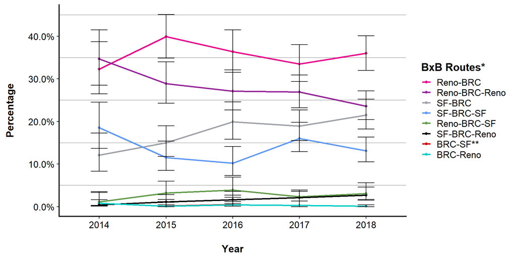

Error bars indicate the upper and lower bounds of the 95% confidence intervals.

* Participants selected all option(s) that applied. Data in the plot above and table below represent participants who reported traveling to BRC via Burner Express Bus.  
** The option "From Black Rock City to San Francisco" was provided in the online survey every year, however in most years the option was not selected.

|  | 2014 Percent | 2014 MoE +/- % |  | 2015 Percent | 2015 MoE +/- % |  | 2016 Percent | 2016 MoE +/- % |  | 2017 Percent | 2017 MoE +/- % |  | 2018 Percent | 2018 MoE +/- % |
| --- | --- | --- | --- | --- | --- | --- | --- | --- | --- | --- | --- | --- | --- | --- |
| Reno-BRC | 32.3 | 6.1 |  | 39.9 | 5.1 |  | 36.4 | 5.1 |  | 33.5 | 4.3 |  | 36.0 | 3.9 |
| Reno-BRC-Reno | 34.7 | 6.5 |  | 28.9 | 4.9 |  | 27.1 | 4.7 |  | 26.9 | 3.9 |  | 23.6 | 3.3 |
| SF-BRC | 12.1 | 4.5 |  | 15.0 | 3.5 |  | 19.9 | 4.3 |  | 18.9 | 3.5 |  | 21.5 | 3.5 |
| SF-BRC-SF | 18.5 | 5.3 |  | 11.5 | 3.3 |  | 10.2 | 3.3 |  | 16.0 | 3.5 |  | 13.1 | 2.9 |
| Reno-BRC-SF | 1.1 | 1.4 |  | 3.2 | 2.0 |  | 3.9 | 2.2 |  | 2.3 | 1.2 |  | 3.1 | 1.8 |
| SF-BRC-Reno | 0.4 | 0.6 |  | 1.1 | 1.0 |  | 1.6 | 1.4 |  | 2.1 | 1.2 |  | 2.7 | 1.4 |
| BRC-SF** | NA | NA |  | 0.2 | 0.4 |  | 0.5 | 0.8 |  | NA | NA |  | NA | NA |
| BRC-Reno | 0.8 | 1.2 |  | 0.1 | 0.2 |  | 0.4 | 0.4 |  | 0.3 | 0.6 |  | 0.1 | 0.2 |

## Use of Burner Express Satellite Shuttle*

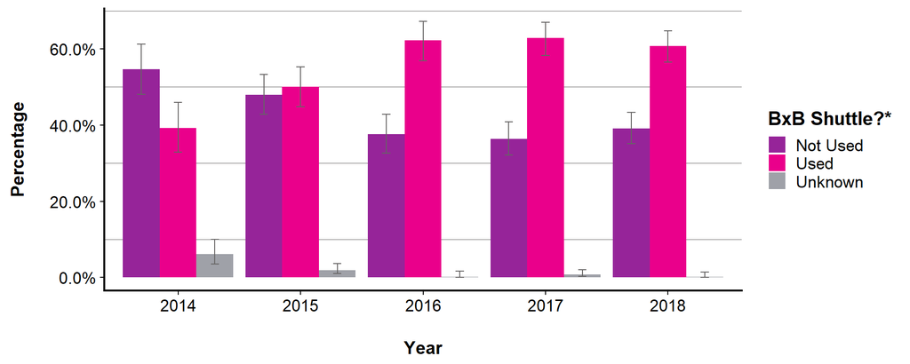

Error bars indicate the upper and lower bounds of the 95% confidence intervals.

* Data in the plot above and table below represent participants who reported traveling to BRC via Burner Express Bus. This question in the online survey specifically references "the satellite shuttle that operates within Black Rock City." The question has undergone minor rewrites in several years for clarity, but these changes were not expected to have (and do not appear to have had) a material effect on participant responses.

|  | 2014 Percent | 2014 MoE +/- % |  | 2015 Percent | 2015 MoE +/- % |  | 2016 Percent | 2016 MoE +/- % |  | 2017 Percent | 2017 MoE +/- % |  | 2018 Percent | 2018 MoE +/- % |
| --- | --- | --- | --- | --- | --- | --- | --- | --- | --- | --- | --- | --- | --- | --- |
| Not Used | 54.7 | 6.7 |  | 48.0 | 5.3 |  | 37.6 | 5.1 |  | 36.4 | 4.3 |  | 39.1 | 4.1 |
| Used | 39.2 | 6.5 |  | 50.1 | 5.3 |  | 62.2 | 5.1 |  | 62.8 | 4.3 |  | 60.7 | 4.1 |
| Unknown | 6.1 | 3.1 |  | 1.9 | 1.4 |  | 0.2 | 0.4 |  | 0.8 | 0.8 |  | 0.2 | 0.4 |

## Use of Burner Express Camping*

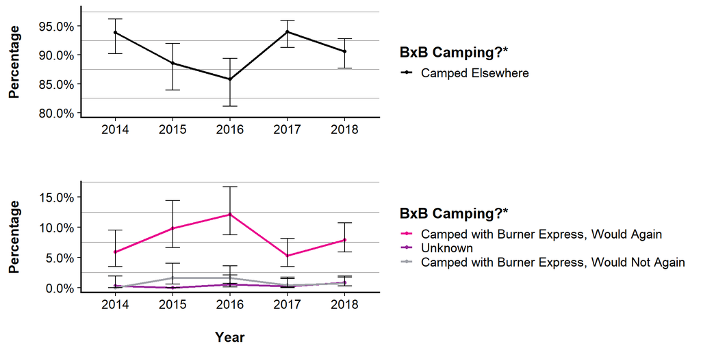

Error bars indicate the upper and lower bounds of the 95% confidence intervals.

* Data in the plot above and table below represent participants who reported traveling to BRC via Burner Express Bus.

|  | 2014 Percent | 2014 MoE +/- % |  | 2015 Percent | 2015 MoE +/- % |  | 2016 Percent | 2016 MoE +/- % |  | 2017 Percent | 2017 MoE +/- % |  | 2018 Percent | 2018 MoE +/- % |
| --- | --- | --- | --- | --- | --- | --- | --- | --- | --- | --- | --- | --- | --- | --- |
| Camped Elsewhere | 93.9 | 2.9 |  | 88.6 | 4.1 |  | 85.8 | 4.1 |  | 94.0 | 2.4 |  | 90.6 | 2.5 |
| Camped with Burner Express, Would Again | 5.9 | 2.9 |  | 9.8 | 3.9 |  | 12.1 | 3.9 |  | 5.3 | 2.2 |  | 7.9 | 2.4 |
| Unknown | 0.3 | 0.6 |  | 0.0 | 0.0 |  | 0.5 | 0.8 |  | 0.2 | 0.4 |  | 0.8 | 0.8 |
| Camped with Burner Express, Would Not Again | 0.0 | 0.0 |  | 1.6 | 1.4 |  | 1.6 | 1.4 |  | 0.4 | 0.6 |  | 0.7 | 0.6 |

**Next:** Event Information: Valued Information Types, Information Sources, BMIR, and GARS